# Introduction to PXDataset2 object

Mohieddin Jafari

2026-04-09 16:15:33

## Resources

Bioconductor packages tagged by “proteomics”, n=188 on 8th Apr2026: https://bioconductor.org/packages/release/BiocViews.html#___Proteomics

```r
knitr::opts_chunk$set(echo = FALSE)
## install.package("BiocManager")

# library(BiocManager)
#
# # Bioconductor packages
# if (!requireNamespace("BiocManager", quietly = TRUE))
#     install.packages("BiocManager")
#
# BiocManager::install("tidyverse")
# BiocManager::install("factoextra")
# BiocManager::install("msdata")
# BiocManager::install("mzR")
# BiocManager::install("rhdf5")
# BiocManager::install("rpx")
# BiocManager::install("MsCoreUtils")
# BiocManager::install("QFeatures")
# BiocManager::install("Spectra")
# BiocManager::install("ProtGenerics")
# BiocManager::install("PSMatch")
# BiocManager::install("pheatmap")
# BiocManager::install("limma")
# BiocManager::install("MSnID")
# BiocManager::install("rawrr")
# BiocManager::install("RforMassSpectrometry/SpectraVis")
#
# install.packages("tidyverse")
```

## Review some points about MS data

- The continuous workflow of separating-separating-separating!
- Three dimensions: Retention time of analyser elution - Mass to charge (M/Z) - Intensity

**Spectrum is the unit of mass spectrometry data**

*TIC (total ion chromatogram) plot*: The intensities of all ions in each mass spectrometer scan (within a given time period) are summed and plotted as a function of time. *Base peak chromatogram plot*: The intensity of the base peak (the most intense ion in each mass spectrum) is plotted as a function of time (Note that the base peak should not be confused with the baseline, which represents the constant background signal of the instrument). *XIC or EIC plot*: The intensity of a specific analyte at a chosen m/z value (either total or base peak intensity) is isolated and plotted as a function of time.

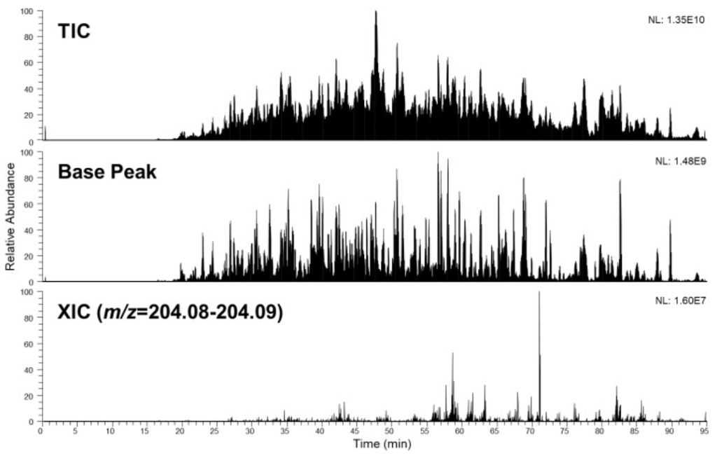

Chromatogram plots

## Group Activity

Check this file “https://github.com/jafarilab/MSProt2026/blob/main/GroupActivity_20Apr.qmd”.

## Getting data

Get to know the ProteomeXchange Consortium: Established to create globally coordinated, standardized pipelines for data submission and dissemination across major proteomics repositories, the Consortium promotes open data policies in proteomics.

`proteomexchange.org`

```r
#Direct accessing data
library(rpx)
library(tidyr)
px <- PXDataset("PXD022816")
pxget(px, grep("mzID", pxfiles(px))[1:3]) # It might take time for the local access
pxget(px, grep("mzML", pxfiles(px))[1:3]) # It might take time for the local access

(px <- PXDataset("PXD000001"))
(pxfiles(px)) # file names of the object

fn <- "TMT_Erwinia_1uLSike_Top10HCD_isol2_45stepped_60min_01-20141210.mzML"
mzf <- pxget(px, fn)

pxtax(px) # taxonomic name
pxref(px) # bibliography ref



pxget(px, "erwinia_carotovora.fasta")
pxget(px, "README.txt") # a vector defining the files to be found, try to find it on your device.
# Some files are accessible remotely and some of them from local cashing mechanism.
pxfiles(px) %>% str() # To check

(f <- pxget(px, "TMT_Erwinia_1uLSike_Top10HCD_isol2_45stepped_60min_01-20141210.mzML"))
basename(f)
```

## MS example data: msdata

```r
# Various Mass Spectrometry raw data example files for proteomics and metabolomics
library(msdata)
proteomics()
```

```
## [1] "MRM-standmix-5.mzML.gz"
## [2] "MS3TMT10_01022016_32917-33481.mzML.gz"
## [3] "MS3TMT11.mzML"
## [4] "TMT_Erwinia_1uLSike_Top10HCD_isol2_45stepped_60min_01-20141210.mzML.gz"
## [5] "TMT_Erwinia_1uLSike_Top10HCD_isol2_45stepped_60min_01.mzML.gz"
```

```r
ident()
```

```
## [1] "TMT_Erwinia_1uLSike_Top10HCD_isol2_45stepped_60min_01-20141210.mzid"
```

```r
quant()
```

```
## [1] "cptac_a_b_peptides.txt"
```

### Quiz 1 (GA_4)

Visit `gosocrative.com` and enter room name `FIN2026`

## Raw MS data

- We need to convert binary-vendor-specific formats to open formats such as mzML, mzXML.
- mzML is the most recent format.
- proteowizard msconvert: https://proteowizard.sourceforge.io/ or search in Google msconvert GUI
- ThermoRawFileParser: https://github.com/compomics/ThermoRawFileParser
- To check all MS-related data format: https://en.wikipedia.org/wiki/Mass_spectrometry_data_format

## MS data from R prospective

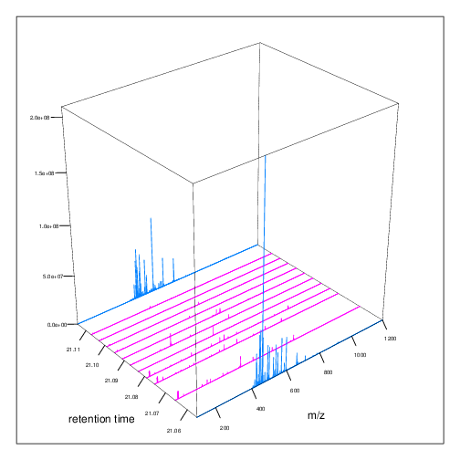

Three dimensions

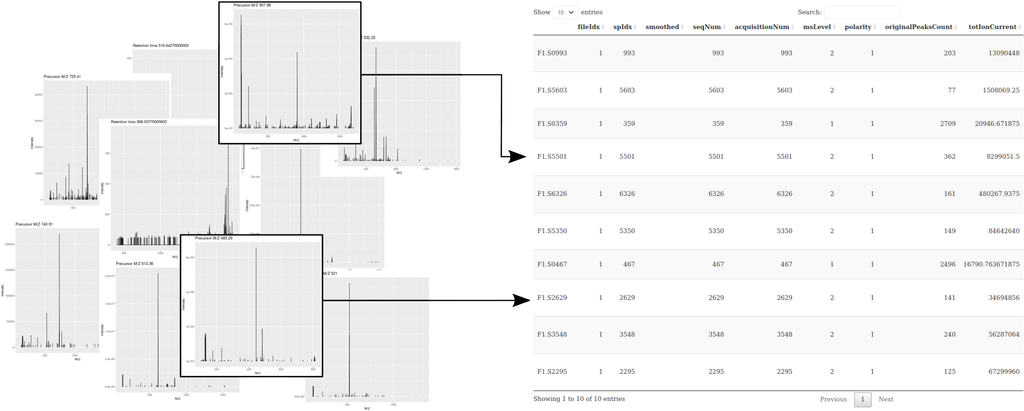

How it looks in R